# report_1 slides

## Tracking CDMRP Awards: A pilot

*Juan Pablo Alperin, Asura Enkhbayar, Lauren Maggio*

Project repository with code, data, and other materials: [Github](https://github.com/ScholCommLab/tracking-grants)

[figure not shown]

## Part 0 - Goals/Overview

### We hope this pilot data can...

- enhance CDMRP's current data set by providing additional metadata (e.g., PMID, PMCID, DOI)
- extend CDMRP's data set to include Altmetric indicators (e.g., Twitter accounts, Facebook posts), clinical trial data and open access status
- provide a sense of future areas of exploration

### We are not ...

- providing a detailed assessment of grants, papers, or programs
- evaluating the quality of the work, efficiency of the programs, or measuring if they are meeting their stated objectives.

**Citations ≠ quality, Altmetrics ≠ public value, News ≠ saliency**

## Part 1 - Data Gathering and Enhancement

### Overview of the data pipeline

[figure not shown]

### Input data and matched results

|  | References | Found Crossref | Unique articles | Awards |
| --- | --- | --- | --- | --- |
| Prostate Cancer Research Program (PCRP) | 8315 | 7434 | 6258 | 1976 |
| Neurofibromatosis Research Program (NFRP) | 648 | 624 | 568 | 186 |
| Peer Reviewed Orthopaedic Research Program (PRORP) | 354 | 335 | 271 | 95 |
| Tuberous Sclerosis Complex Research Program (TSCRP) | 208 | 202 | 198 | 85 |
| Sum | 9525 | 8595 | 7295 | 2342 |

### Coverage of DOIs (n=7289) in the WoS (21.9%) and Twitter (39.1%)

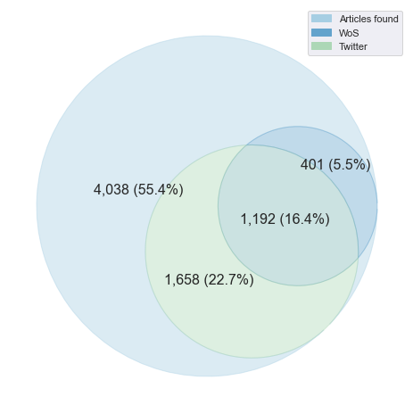

### Publications and awards over years

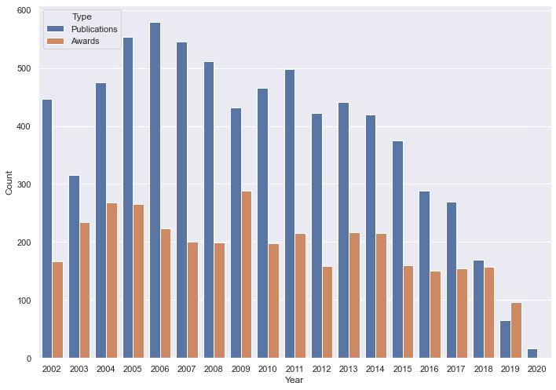

### Clinical Trials

These trials were associated with 231 articles in our dataset funded by **182 grants**.

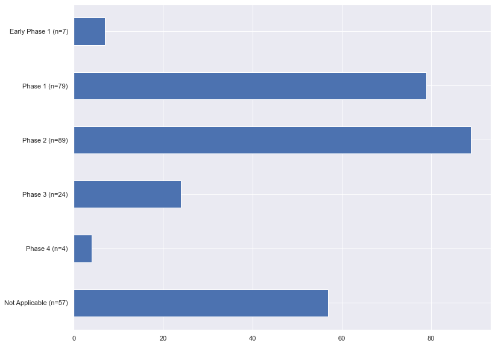

## Part 2 - Data on the award level

#### Overview of awards per research program

|  | Awards | Avg Size [millions] |
| --- | --- | --- |
| PCRP | 1976 | 0.46 |
| NFRP | 186 | 0.94 |
| PRORP | 95 | 1.35 |
| TSCRP | 85 | 0.45 |

### Award amount per research program

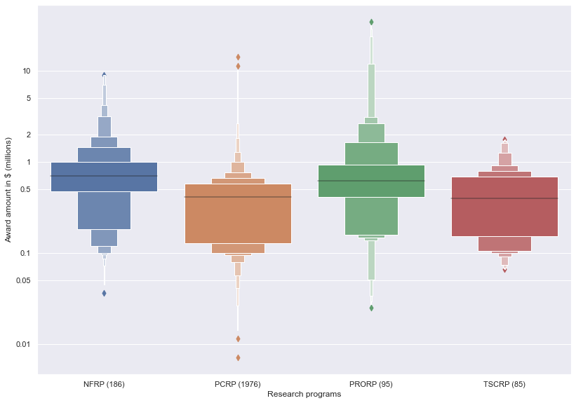

### Award types

Manual categorization of 90+ mechanism types across all research programs

|  | Categorization | Awards | Avg. size [millions] |
| --- | --- | --- | --- |
| Idea | Idea and Concept Development | 1176 | 0.49 |
| ECR | Early Career Researchers Awards (Training, Fel... | 861 | 0.27 |
| Other | Other Awards | 178 | 0.96 |
| Non-academic | E.g., Training for Physicians | 61 | 0.65 |
| Health Disparity | Health Disparity Awards | 59 | 0.48 |
| HBCU | Historically Black Colleges and Universities | 58 | 0.51 |
| Consortium | (Clinical) Consortium Awards | 44 | 3.51 |
| Research Site | Development of centers and other research sites | 40 | 1.25 |
| Impact | Impact Awards | 22 | 1.99 |
| Clinical Trial | Clinical Trial Awards | 18 | 1.22 |

### Number of publications per research program

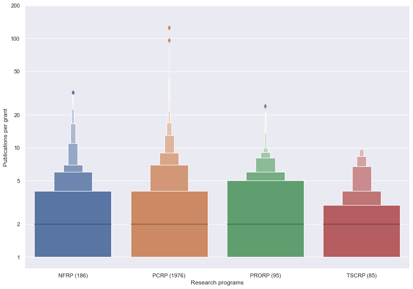

### Award amount by categories

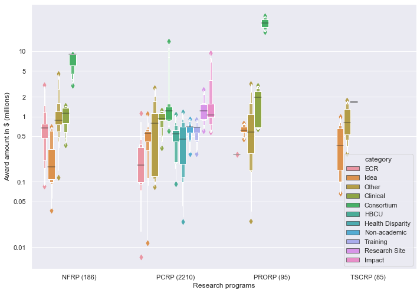

### Number of publication by award category

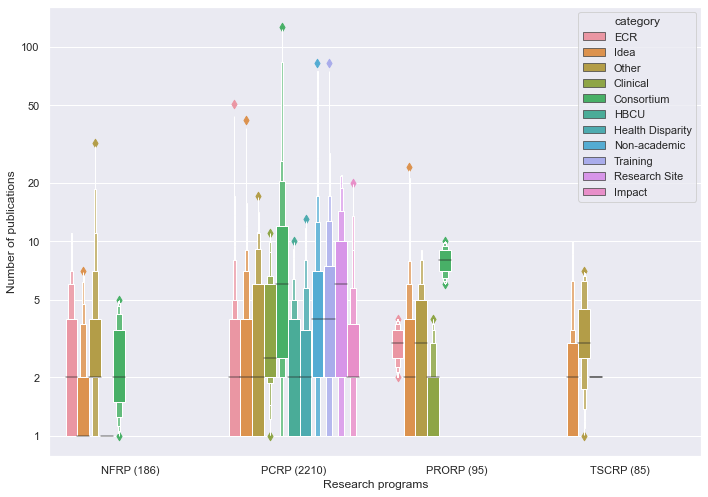

### Award size vs number of publications (without Consortium)

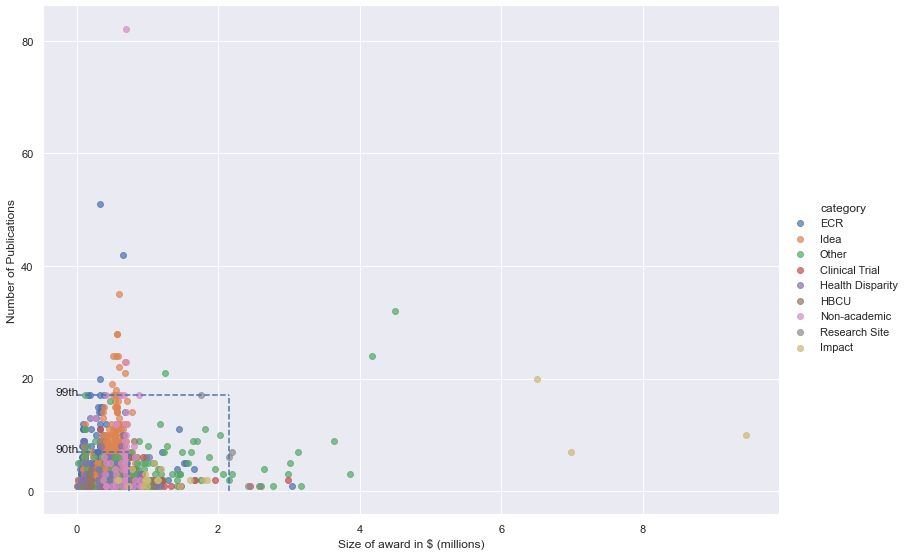

## Part 3 - Not all awards are the same

### Measuring award outputs

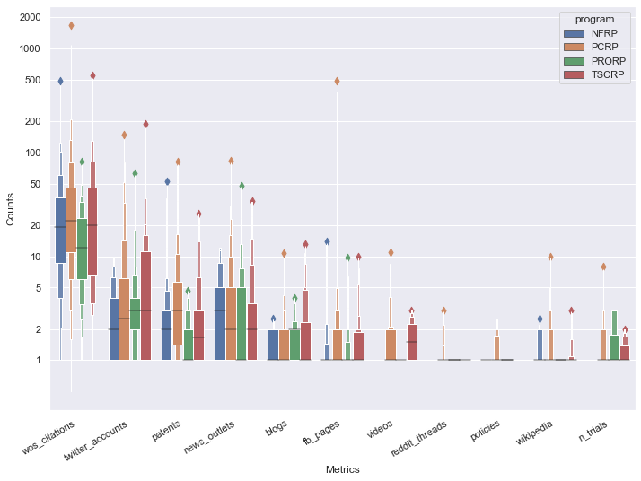

### Pairplot on the award level

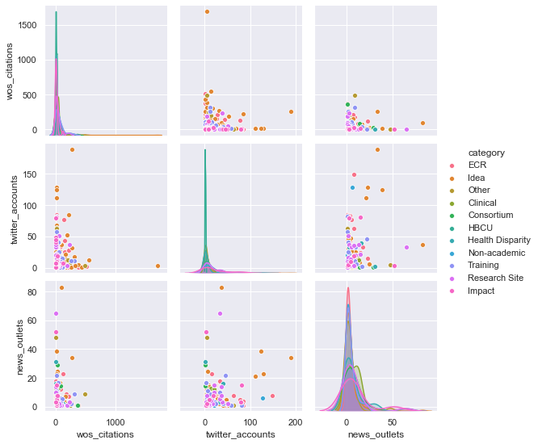

### Outputs over award size

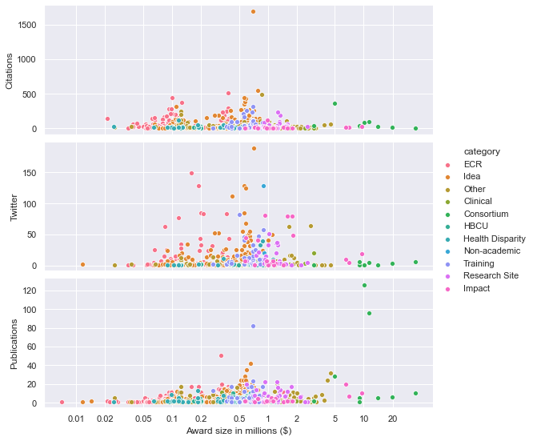

## Part 4 - Limitations

### Scope and results

- Current pilot is limited to the 4 selected programs
- Results might differ with different programs

### Data quality and completeness

- We are not fetching papers, only using data provided
- We are matching citation strings to Crossref database: there’s an error rate in this matching
- Citations from WoS only count citing papers from other WoS papers
- Altmetric and Unpaywall are also known to have some errors (as with any database drawn from searching the Web).

## Part 5 - Future Directions

- Data on the Open Access status (through Unpaywall API)
  - Quantify the public access to research outputs generated by research programs
  - Is there an Open Access advantage (citations, altmetrics, other metrics) observeable in the data?
- Provide a more comprehensive overview of identifiers
  - Based on the DOI we are currently retrieving PMIDs
  - Using the same method, we can attempt to retrieve PMCIDs instead of relying on the internal conversion tools provided by the NCBI which have been unreliable